# Biostat M280 Homework 3

Haowen Xu haowenxu930622@outlook.com

## Q1. LA City Employee Payroll

**1.Solution:**

Transform data and save it as RDS file:

```r
library("tidyverse")
pay <- read_csv('/home/m280data/la_payroll/City_Employee_Payroll.csv')
names(pay) <- str_replace_all(names(pay), " ", "_")
pay <- mutate(pay, other_pay = Total_Payments - Base_Pay - Overtime_Pay) %>%         select(Year, Department_Title, Total_Payments, Base_Pay, Overtime_Pay,
                                                                                            other_pay, Row_ID)
saveRDS(pay, file = "payroll.rds")
```

Here is my Shiny code:

```r
library("tidyverse")
library("shiny")
library("reshape2")

#read in data
pay <- readRDS("/data/payroll.rds")

# Define UI ----
ui <- fluidPage(
  titlePanel("LA City Employee Payroll"),

  sidebarLayout(
    sidebarPanel(helpText("LA city employee payroll information from 2013 to
                          2018."),
                 selectInput("question",
                             label = "Choose a question to display:",
                             choices = c("Total payroll(Q2)",
                                         "Who earned most?(Q3)",
                             "Which department earned most?(Q4)",
                             "Which department cost most?(Q5)"),
                             selected = "Total payroll"),
                 numericInput(inputId = "size",
                              label = "Number of observations to view(Q3~5):",
                              value = 5),
                 selectInput("year",
                             label = "Choose year of interest(Q2~5):",
                             choices = c("2013", "2014", "2015", "2016",
                                         "2017", "2018"),
                             selected = "2017"),
                 selectInput("method",
                             label = "Method(Q4):",
                             choices = c("Median", "Mean"),
                             selected = "Median")),
    mainPanel(plotOutput("myplot"))
  )

)

# Define server logic ----
server <- function(input, output) {

  output$myplot <- renderPlot({

    if(input$question == "Total payroll(Q2)"){
      data <- summarize(group_by(pay, Year), base = sum(Base_Pay,
                                                        na.rm = TRUE),
                        over = sum(Overtime_Pay, na.rm = TRUE),
                        other = sum(other_pay, na.rm = TRUE))
      data <- melt(data, id.var = "Year")
      ggplot(data, aes(x = reorder(as.factor(Year), -value), y = value,
                       fill = variable)) +
        geom_bar(stat="identity") +
        ggtitle("Total payroll by LA city") +
        xlab("Year") + ylab("Total Payment") +
        scale_y_continuous()
    }else if(input$question == "Who earned most?(Q3)"){
      data <- arrange(pay, desc(Total_Payments)) %>%
        filter(Year == as.character(input$year)) %>%
        head(input$size)%>%
        mutate(rank = dense_rank(desc(Total_Payments))) %>%
        select(Base_Pay, Overtime_Pay, other_pay, rank)
      data <- melt(data, id.var = "rank")
      ggplot(data, aes(x = as.factor(rank), y = value, fill = variable)) +
        geom_bar(stat="identity") +
        ggtitle("Who earned most?") +
        xlab("ID") + ylab("Total Payment") + scale_y_continuous()
    }else if(input$question == "Which department earned most?(Q4)"){
      data <- filter(pay, Year == as.character(input$year)) %>%
        group_by(Department_Title) %>%
        summarize(mean_tot = mean(Total_Payments, na.rm = TRUE),
                  mean_base = mean(Base_Pay, na.rm = TRUE),
                  mean_over = mean(Overtime_Pay, na.rm = TRUE),
                  mean_other = mean(other_pay, na.rm = TRUE),
                  median_base = median(Base_Pay, na.rm = TRUE),
                  median_over = median(Overtime_Pay, na.rm = TRUE),
                  median_other = median(other_pay, na.rm = TRUE),
                  median_tot = median(Total_Payments, na.rm = TRUE))
      if(input$method == "Median"){
        data <- arrange(data, desc(median_tot)) %>%
          head(input$size) %>%
          select(Department_Title, median_base, median_over, median_other)
        data <- melt(data, id.var = "Department_Title")
        ggplot(data, aes(x = reorder(as.factor(Department_Title), -value),
                         y = value,
                         fill = variable)) +
          geom_bar(stat="identity") +
          ggtitle("Which department earned most by median?") +
          xlab("Department") + ylab("Total Earned") +
          scale_y_continuous() +
          theme(axis.text.x = element_text(angle = 90, hjust = 1))
      }else if(input$method == "Mean"){
        data <- arrange(data, desc(mean_tot)) %>%
          head(input$size) %>%
          select(Department_Title, mean_base, mean_over, mean_other)
        data <- melt(data, id.var = "Department_Title")
        ggplot(data, aes(x = reorder(as.factor(Department_Title), -value),
                         y = value,
                         fill = variable)) +
          geom_bar(stat="identity") +
          ggtitle("Which department earned most by mean?") +
          xlab("Department") + ylab("Total Earned") +
          scale_y_continuous() +
          theme(axis.text.x = element_text(angle = 90, hjust = 1))
      }
    }else if(input$question == "Which department cost most?(Q5)"){
      data <- filter(pay, Year == as.character(input$year)) %>%
        group_by(Department_Title) %>%
        summarize(tot = sum(Total_Payments), base = sum(Base_Pay),
                  over = sum(Overtime_Pay), other = sum(other_pay)) %>%
        arrange(desc(tot)) %>%
        head(input$size) %>%
        select(Department_Title, base, over, other)
      data <- melt(data, id.var = "Department_Title")
      ggplot(data, aes(x = reorder(as.factor(Department_Title), -value),
                       y = value,
                       fill = variable)) +
        geom_bar(stat="identity") +
        ggtitle("Which department cost the most?") +
        xlab("Department") + ylab("Total cost") +
        scale_y_continuous() +
        theme(axis.text.x = element_text(angle = 90, hjust = 1))
    }
  })
}

# Run the app ----
shinyApp(ui = ui, server = server)
```

**2.Solution:**

Total payroll each year:

```r
library("tidyverse")
pay <- readRDS("shinyapps/data/payroll.rds")
data <- summarize(group_by(pay, Year), base = sum(Base_Pay),
                        over = sum(Overtime_Pay, na.rm = TRUE),
                        other = sum(other_pay, na.rm = TRUE))
data
```

```
## # A tibble: 6 x 4
##    Year        base       over      other
##   <dbl>       <dbl>      <dbl>      <dbl>
## 1  2013 3792236138. 374443861. 339098784.
## 2  2014 3853034418. 471294633. 401441168.
## 3  2015 3965080709. 553011310. 365129304.
## 4  2016 4093472170. 573420719. 372524729.
## 5  2017 4329128425. 639473544. 378221913.
## 6  2018 3475755615. 524883354. 322753628.
```

**3.Solution:**

Example: Top 10 payroll in 2015.

```r
data <- arrange(pay, desc(Total_Payments)) %>%
        filter(Year == as.character(2015)) %>%
        head(10)%>%
        mutate(rank = dense_rank(desc(Total_Payments))) %>%
        select(Row_ID, Total_Payments, Base_Pay, Overtime_Pay, other_pay, rank)
data
```

```
## # A tibble: 10 x 6
##    Row_ID              Total_Payments Base_Pay Overtime_Pay other_pay  rank
##    <chr>                        <dbl>    <dbl>        <dbl>     <dbl> <int>
##  1 5-1883455278ctFu           499382.  298054.           0    201328.     1
##  2 5-2015036291ctFu           482792.  221569.       56265.   204958.     2
##  3 5-2050330925ctFu           477138.  298054.           0    179084.     3
##  4 5-1081092723ctFu           448594.  120829.      311316.    16450.     4
##  5 5-3390480966ctFu           444046.  220588.        6624.   216833.     5
##  6 5-2916909498ctFu           437881   221569.       45742.   170569.     6
##  7 5-1936095583ctFu           434746.  221569.       32140.   181037.     7
##  8 5-4158231751ctFu           434146.  222442.       45061.   166644      8
##  9 5-899857787ctFu            428507.  222005.       40699.   165803.     9
## 10 5-2720285819dwp526…        424867.  130015.           0    294852.    10
```

**4.Solution:**

Example: Top 10 department earned most in 2014 using median.

```r
data <- filter(pay, Year == as.character(2014)) %>%
  group_by(Department_Title) %>%
  summarize(median_base = median(Base_Pay, na.rm = TRUE),
            median_over = median(Overtime_Pay, na.rm = TRUE),
            median_other = median(other_pay, na.rm = TRUE),
            median_tot = median(Total_Payments, na.rm = TRUE)) %>%
  arrange(desc(median_tot)) %>%
  head(10) %>%
  select(Department_Title, median_tot, median_base, median_over, median_other)
data
```

```
## # A tibble: 10 x 5
##    Department_Title         median_tot median_base median_over median_other
##    <chr>                         <dbl>       <dbl>       <dbl>        <dbl>
##  1 Fire (LAFD)                 149303.      86023.     41129.      9.93e+ 3
##  2 Information Technology …    104195.      90275.         0       3.65e+ 3
##  3 Water And Power (DWP)       103641.      78941.      7618.      7.17e+ 3
##  4 Police (LAPD)               101602.      89610.      3101.      5.70e+ 3
##  5 City Attorney               101332.      89568          0       6.28e+ 3
##  6 City Administrative Off…     96867.      96394.         0       6.00e+ 2
##  7 Public Works - Contract…     96677.      84771.        75.8     7.70e+ 3
##  8 Public Works - Engineer…     95122.      94848          0       1.24e+ 3
##  9 Building and Safety          94800.      84101.       792.      4.49e+ 3
## 10 Emergency Management         90018.      85526.         0       4.89e-12
```

**5.Solution:**

Example: Top 6 department cost the most in 2018.

```r
data <- filter(pay, Year == as.character(2018)) %>%
  group_by(Department_Title) %>%
  summarize(tot = sum(Total_Payments), base = sum(Base_Pay),
            over = sum(Overtime_Pay), other = sum(other_pay)) %>%
  arrange(desc(tot)) %>%
  head(6) %>%
  select(Department_Title, tot, base, over, other)
data
```

```
## # A tibble: 6 x 5
##   Department_Title                  tot       base       over      other
##   <chr>                           <dbl>      <dbl>      <dbl>      <dbl>
## 1 Police (LAPD)             1174316490. 967669554. 114550211.  92096724.
## 2 Water And Power (DWP)     1085623116. 797566609. 175072555. 112983952.
## 3 Fire (LAFD)                483144683. 290968442. 150262700.  41913540.
## 4 Airports (LAWA)            253410190. 210903070.  25761381.  16745739.
## 5 Public Works - Sanitation  192858765. 170307571.  13589401.   8961794.
## 6 Recreation And Parks       136945300. 130128609.   2700233.   4116459.
```

**6.Solution:**

```r
data <- filter(pay, Year == as.character(2018)) %>%
  group_by(Department_Title) %>%
  summarize(tot = sum(Total_Payments), base = sum(Base_Pay),
            over = sum(Overtime_Pay), other = sum(other_pay)) %>%
  arrange(desc(base)) %>%
  head(5) %>%
  select(Department_Title, base)
data
```

```
## # A tibble: 5 x 2
##   Department_Title                base
##   <chr>                          <dbl>
## 1 Police (LAPD)             967669554.
## 2 Water And Power (DWP)     797566609.
## 3 Fire (LAFD)               290968442.
## 4 Airports (LAWA)           210903070.
## 5 Public Works - Sanitation 170307571.
```

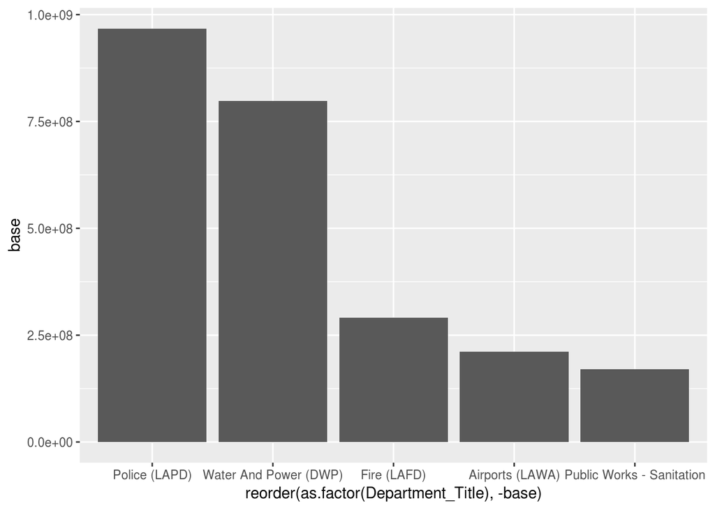

```r
ggplot(data, aes(x = reorder(as.factor(Department_Title), -base), y = base)) +
  geom_bar(stat="identity")
```

**7.Solution:**

Here is the link to my Shiny app: https://haowenxu.shinyapps.io/shinyapps/

## Q2. LA City Parking War

Connect to the data base:

```r
library("DBI")
library("RSQLite")
library("tidyverse")
library("lubridate")
parking <- dbConnect(RSQLite::SQLite(),
              dbname = "/home/m280data/la_parking/LA_Parking_Citations.sqlite")
dbListTables(parking)
```

```
## [1] "latix"
```

```r
parking_sql <- dplyr::tbl(parking, "latix")
parking_sql %>% print(width = Inf)
```

```
## # Source:   table<latix> [?? x 24]
## # Database: sqlite 3.22.0
## #   [/home/m280data/la_parking/LA_Parking_Citations.sqlite]
##    Ticket_number Issue_DateTime Issue_Year Issue_Month Issue_Day Issue_Hour
##            <dbl>          <dbl>      <int>       <int>     <int>      <int>
##  1    4272349605     1451512860       2015          12        30         22
##  2    4272349616     1451513100       2015          12        30         22
##  3    4272821512     1451496300       2015          12        30         17
##  4    4272821523     1451497080       2015          12        30         17
##  5    4272821534     1451498820       2015          12        30         18
##  6    4272889353     1451452440       2015          12        30          5
##  7    4274301964     1451909100       2016           1         4         12
##  8    1112509506     1450702500       2015          12        21         12
##  9    1112509510     1450703100       2015          12        21         13
## 10    1112509926     1450705200       2015          12        21         13
```

[output cut: 49 more lines]

**1.Solution:**

Total number of tickects:

7656418

Number of tickets each year:

2015 | 1068245  
2016 | 2177956  
2017 | 2235243  
2018 | 1976451  
2019 | 124458

Here is my R code:

```r
#Simplify data
parking_data <- select(parking_sql, Ticket_number, Issue_DateTime, Issue_Year,
                       Issue_Month, Issue_Day, Issue_Hour, Issue_Wday,
                       Make, Color, Fine_amount, Violation_code,
                       Violation_Description)
#Total number of tickets
summarize(parking_data, n = n()) %>% collect()
```

```
## # A tibble: 1 x 1
##         n
##     <int>
## 1 7656418
```

```r
#Tickects by year
ticket <- filter(parking_data, Issue_Year > 0)%>%
  group_by(Issue_Year) %>%
  summarize(n = n()) %>%
  collect()
ticket
```

```
## # A tibble: 5 x 2
##   Issue_Year       n
##        <int>   <int>
## 1       2015 1068245
## 2       2016 2177956
## 3       2017 2235243
## 4       2018 1976451
## 5       2019  124458
```

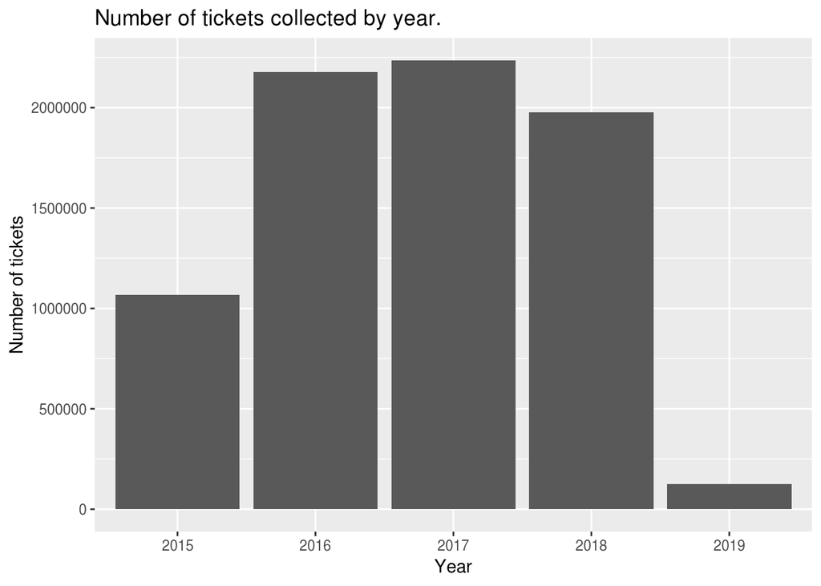

```r
#Plot
ggplot(ticket, aes(x = as.factor(Issue_Year), y = n)) +
  geom_bar(stat = "identity") +
  ggtitle("Number of tickets collected by year.") +
  xlab("Year") + ylab("Number of tickets")
```

**2.Solution:**

You are most likely to get a ticket at :

Hour | 12 p.m.

Month day | 13

Month | August

You are least likely to get a ticket at :

Hour | 5 a.m.

Month day | 31

Month | Feburary

Here is my R code:

```r
#Distribution of number of ticket by month
month <- filter(parking_data, Issue_Month > 0) %>%
  group_by(Issue_Month) %>%
  summarize(n = n()) %>%
  arrange(desc(n)) %>%
  collect()
head(month, 1)
```

```
## # A tibble: 1 x 2
##   Issue_Month      n
##         <int>  <int>
## 1           8 752904
```

```r
tail(month, 1)
```

```
## # A tibble: 1 x 2
##   Issue_Month      n
##         <int>  <int>
## 1           2 512428
```

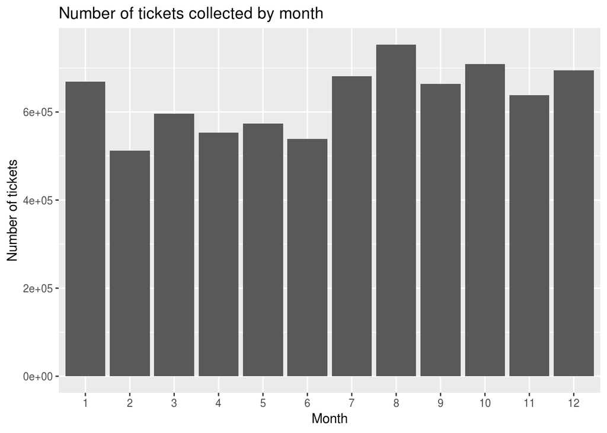

```r
ggplot(month, aes(x = as.factor(Issue_Month), y = n)) +
  geom_bar(stat = "identity") +
  ggtitle("Number of tickets collected by month") +
  xlab("Month") + ylab("Number of tickets")
```

```r
#Distribution of number of ticket by day
day <- filter(parking_data, Issue_Day > 0) %>%
  group_by(Issue_Day) %>%
  summarize(n = n()) %>%
  arrange(desc(n)) %>%
  collect()
head(day, 1)
```

```
## # A tibble: 1 x 2
##   Issue_Day      n
##       <int>  <int>
## 1        13 267419
```

```r
tail(day, 1)
```

```
## # A tibble: 1 x 2
##   Issue_Day      n
##       <int>  <int>
## 1        31 157356
```

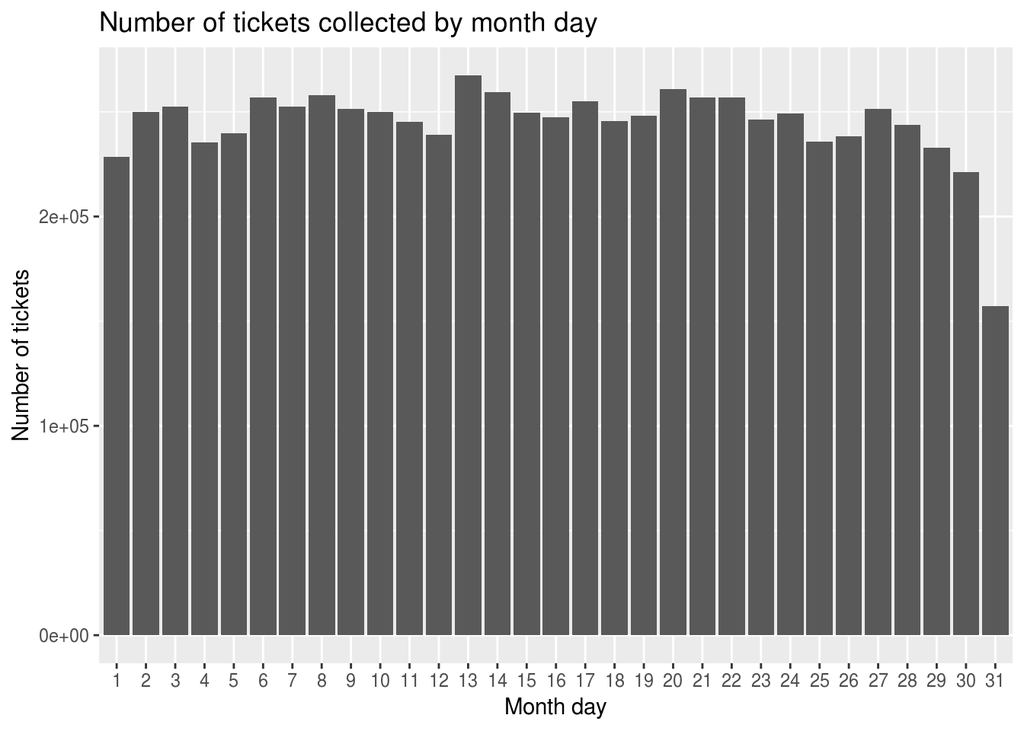

```r
ggplot(day, aes(x = as.factor(Issue_Day), y = n)) +
  geom_bar(stat = "identity") +
  ggtitle("Number of tickets collected by month day") +
  xlab("Month day") + ylab("Number of tickets")
```

```r
#Distribution of number of ticket by week day
wday <- filter(parking_data, Issue_Wday > 0) %>%
  group_by(Issue_Wday) %>%
  summarize(n = n()) %>%
  arrange(desc(n)) %>%
  collect()
head(wday, 1)
```

```
## # A tibble: 1 x 2
##   Issue_Wday       n
##        <dbl>   <int>
## 1          3 1468900
```

```r
tail(wday, 1)
```

```
## # A tibble: 1 x 2
##   Issue_Wday      n
##        <dbl>  <int>
## 1          1 369564
```

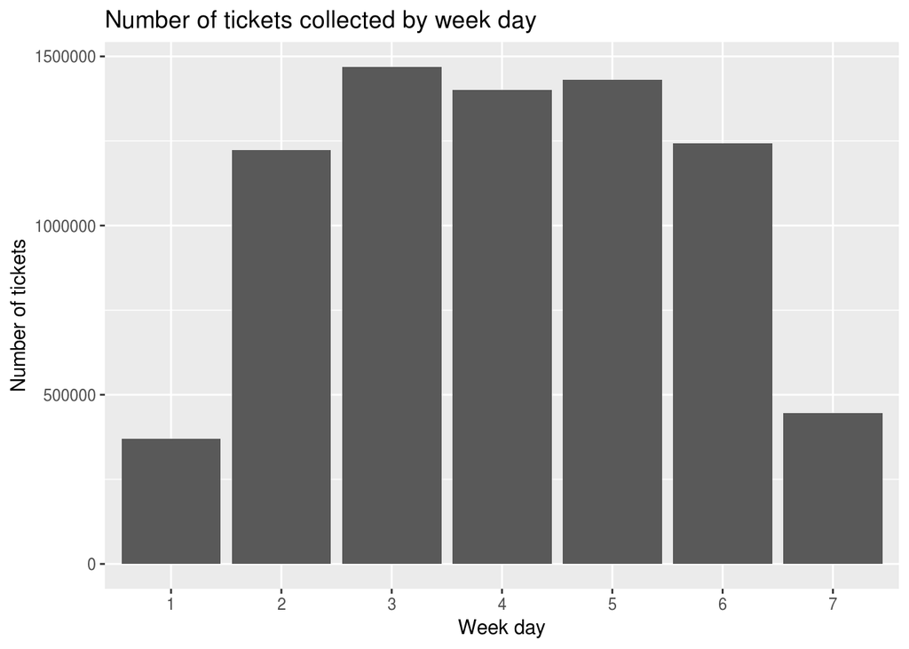

```r
ggplot(wday, aes(x = as.factor(Issue_Wday), y = n)) +
  geom_bar(stat = "identity") +
  ggtitle("Number of tickets collected by week day") +
  xlab("Week day") + ylab("Number of tickets")
```

```r
#Distribution of number of ticket by Hour
hour <- filter(parking_data, Issue_Hour > 0) %>%
  group_by(Issue_Hour) %>%
  summarize(n = n()) %>%
  arrange(desc(n)) %>%
  collect()
head(hour, 1)
```

```
## # A tibble: 1 x 2
##   Issue_Hour      n
##        <int>  <int>
## 1         12 975063
```

```r
tail(hour, 1)
```

```
## # A tibble: 1 x 2
##   Issue_Hour     n
##        <int> <int>
## 1          5 53971
```

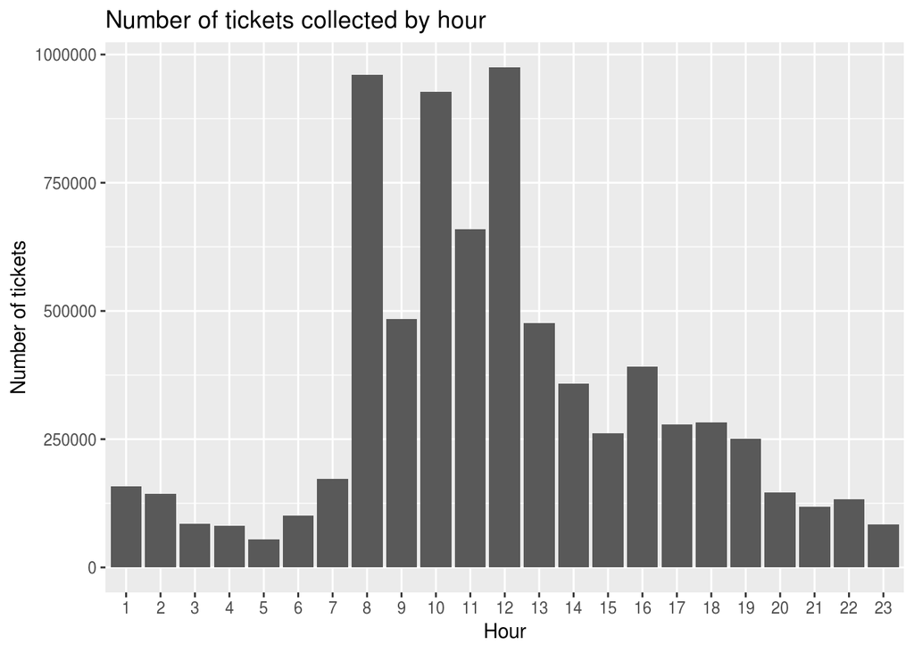

```r
ggplot(hour, aes(x = as.factor(Issue_Hour), y = n)) +
  geom_bar(stat = "identity") +
  ggtitle("Number of tickets collected by hour") +
  xlab("Hour") + ylab("Number of tickets")
```

**3.Solution:**

The car make that receives most citations is: Toyota

Here is my R code:

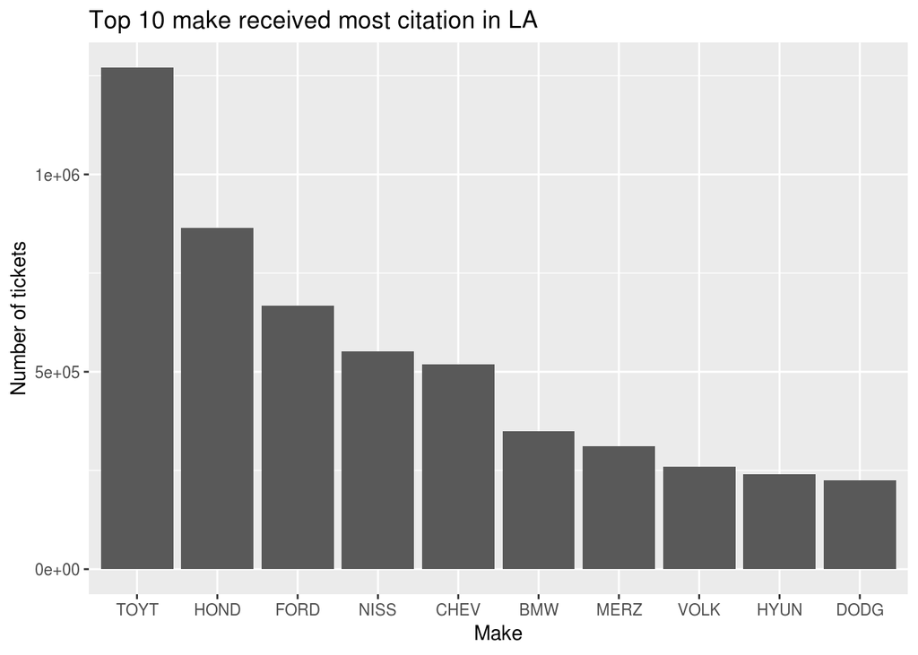

```r
make <- filter(parking_data, is.na(Make) == FALSE) %>%
  group_by(Make) %>%
  summarize(n = n()) %>%
  arrange(desc(n)) %>%
  head(10) %>%
  collect()
ggplot(make, aes(x = reorder(as.factor(Make), -n), y = n)) +
  geom_bar(stat = "identity") +
  ggtitle("Top 10 make received most citation in LA") +
  xlab("Make") + ylab("Number of tickets")
```

**4.Solution:**

Total number of car colors: 103

The color or cars receives most tickets: Black

Here is my R code:

```r
color <- filter(parking_data, is.na(Color) == FALSE) %>%
  group_by(Color) %>%
  summarize(n = n()) %>%
  arrange(desc(n)) %>%
  collect()
nrow(color)
```

```
## [1] 103
```

```r
head(color, 1)
```

```
## # A tibble: 1 x 2
##   Color       n
##   <chr>   <int>
## 1 BK    1652621
```

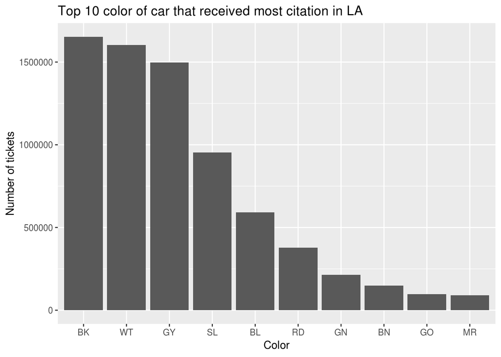

```r
color <- head(color, 10)
ggplot(color, aes(x = reorder(as.factor(Color), -n), y = n)) +
  geom_bar(stat = "identity") +
  ggtitle("Top 10 color of car that received most citation in LA") +
    xlab("Color") + ylab("Number of tickets")
```

**5.Solution:**

The most common ticket type is: NO PARK/STREET CLEAN

Here is my R code:

```r
type <- filter(parking_data, is.na(Violation_Description) == FALSE) %>%
  group_by(Violation_Description) %>%
  summarize(n = n()) %>%
  arrange(desc(n)) %>%
  head(10) %>%
  collect()
print(type, n = 10)
```

```
## # A tibble: 10 x 2
##    Violation_Description        n
##    <chr>                    <int>
##  1 NO PARK/STREET CLEAN   2234699
##  2 METER EXP.             1302155
##  3 RED ZONE                582135
##  4 PREFERENTIAL PARKING    523775
##  5 DISPLAY OF TABS         472750
##  6 NO PARKING              343489
##  7 DISPLAY OF PLATES       211693
##  8 WHITE ZONE              168596
##  9 PARKED OVER TIME LIMIT  156501
## 10 NO STOP/STANDING        138691
```

**6.Solution:**

Total amount of money collected on parking in 2016, 2017, 2018 are:

Year Amount

2016 75026770

2017 76876603

2018 70060345

Here is my R code:

```r
money <- filter(parking_data, is.na(Fine_amount) == FALSE,
                is.na(Issue_Year) == FALSE) %>%
  group_by(Issue_Year, Violation_Description) %>%
  summarize(amount = sum(Fine_amount)) %>%
  arrange(Issue_Year) %>%
  collect()
#Can not apply grepl() when using value from database
money <- filter(money, grepl("PARK", Violation_Description)) %>%
  group_by(Issue_Year) %>%
  summarize(amount = sum(amount)) %>%
  arrange(Issue_Year)
print(money)
```

```
## # A tibble: 5 x 2
##   Issue_Year   amount
##        <int>    <dbl>
## 1       2015 36332176
## 2       2016 75026770
## 3       2017 76876603
## 4       2018 70060345
## 5       2019  4427452
```

**7.Solution:**

I have never been ticketed in LA county.

Close connection to the database:

```r
dbDisconnect(parking)
```